# Data visualization

## Introduction to ggplot

In this lesson, you will learn how to plot graphs or figures in R. When working with data, it is good practice to plot the data to evaluate it. This can help identify trends or even problems in the data. Also need plotting for displaying and communicating results. There are basic plotting functions in R, but we will use the functions in the package `ggplot2`.

We will use the package `ggplot2` to produce visualizations in this class:

- ggplot works well with the “tidy” data and data manipulations that you did in the previous lesson with `dplyr`
- ggplot is very customizable, allowing you to alter titles, colors, style, etc. with R code.
- ggplot produces pretty graphs.

### Install `ggplot2`

To use `ggplot2`, you must first install it. You can use the packages tab on the lower right hand pane of Rstudio or with the code:

```
install.packages('ggplot2')
```

You only have to install the `ggplot2` package once, but don’t forget to load it in *each* time you want to use it.

```r
library(ggplot2)
```

### Getting the data ready

In this lesson, let’s start with the movie data that you used in the homework of the `dplyr` [lesson](https://maryglover.github.io/bio331/lessons/data-manip/data-manip-exercise.html#Homework_Exercise). Making graphs is a great way to explore the data.

Go ahead and load in the data and also run the code from the lesson to make the data numeric.

```r
movies <- read.csv('data/movies.csv')

library(dplyr)
movies <- movies |>
  mutate(budget = as.numeric(budget),
         intgross = as.numeric(intgross),
         rated = as.factor(rated))
```

We will also simply the data by selecting only some of the columns and reassigning it the name `movies_select`

```r
movies_select <- movies |>
  select(year, title, budget, intgross, rated, metascore, imdb_rating)
```

## Layers

`ggplot2` uses what are called “layers” to plot data. These layers are added on one another to produce the visualization.

The first layer sets the *foundation* and uses the function `ggplot()`. The `ggplot()` function expects:

1. the data you are plotting
2. the aesthetic mapping `aes()`. This provides the columns that will be displayed on the graph. For example, the what column is the x axis and which is the y axis.

Let’s say that we wanted to plot a histogram of the number of of the movies released in each year. A histogram shows the distribution of values, with the value on the x axis. In this case, our x axis will be the year and the number of times is found in the data on the y axis. To do this, we will set the aesthetic for the x axis as the `year` column.

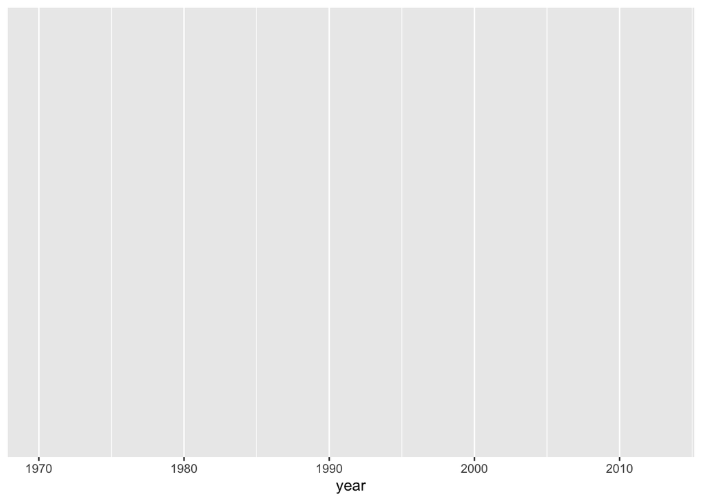

```r
ggplot(data = movies_select, aes(x = year))
```

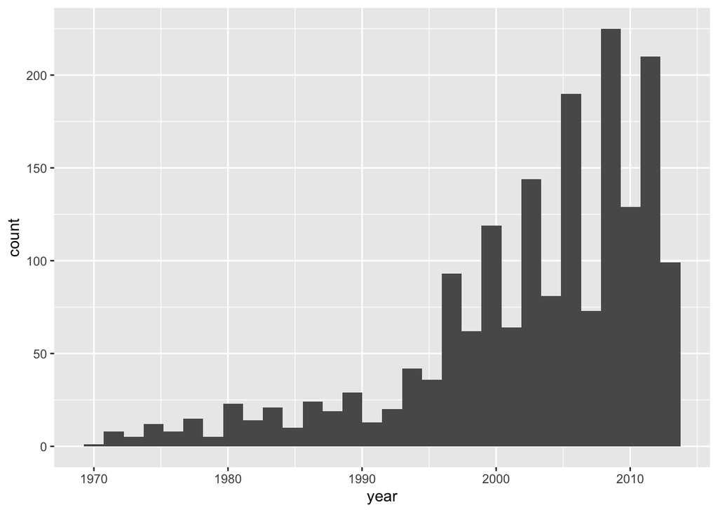

```r
ggplot(data = movies, aes(x = year)) +
  geom_histogram()
```

*What do you notice about the movie release date data?*

**Activity**: Make a histogram using the different movie metascrore.

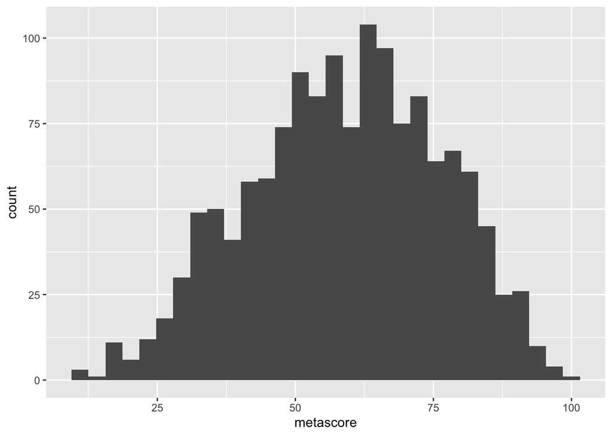

To create different types of plots, you would use a different layer. Some examples are:

- `geom_point`: plots points for a scatterplot
- `geom_bar`: barplot
- `geom_boxplot`: boxplot
- `geom_line`: line graph.

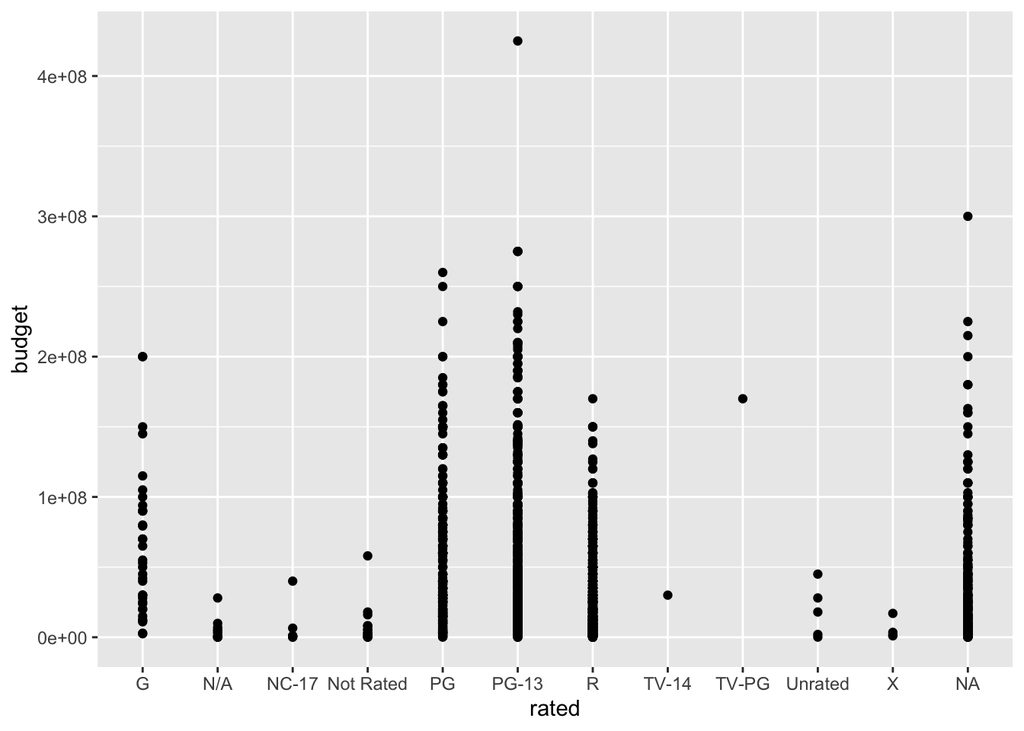

```r
ggplot(data = movies_select, aes(x = rated, y = budget)) +
  geom_point()
```

You could also graph this data with a boxplot, which might make more sense here. A boxplot is a way to show the distribution of data, by displaying the summary statistics, including the median, the 25% and 75% quantiles, and outliers. Here, you need to specify the “group” in the boxplot aesthetic to show what goes into each box should be a separate box.

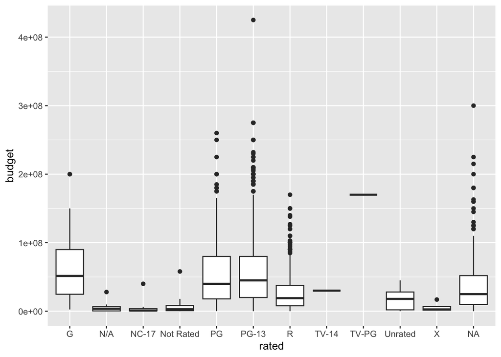

```r
ggplot(data = movies_select, aes(x = rated, y = budget)) +
  geom_boxplot()
```

You can see that some of these boxes, you probably don’t care about. You can combine your `dplyr` functions with `ggplot`. Let’s only look at ratings of G, PG, PG-13, and R. Here, we will resave the data into the `movies_select` object.

```r
movies_select <- movies_select |>
  filter(rated %in% c('G', 'PG', 'PG-13', 'R'))
```

Now, let’s look at the boxplot.

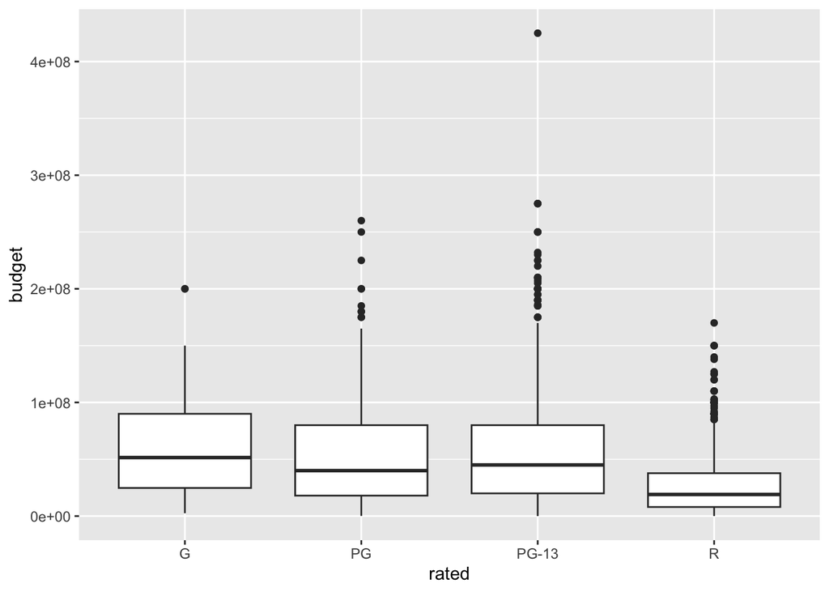

```r
ggplot(data = movies_select, aes(x = rated, y = budget)) +
  geom_boxplot()
```

**Activity**: Make another boxplot, but this time look at the metascore for each movie rating.

## Customizing plots

So far, the plots have just been using the default display settings. In ggplot, you can customize the appearance of the plots using addition code or layers.

### Labels

First, we will use additional layers to add labels, including axis labels and titles. To change the axis labels, we can use the `labs()` layer. In `labs` you can specify changing the x-axis (x), y axis (y), and the title.

We will “add” the `labs()` layer to change the x and y axis labels

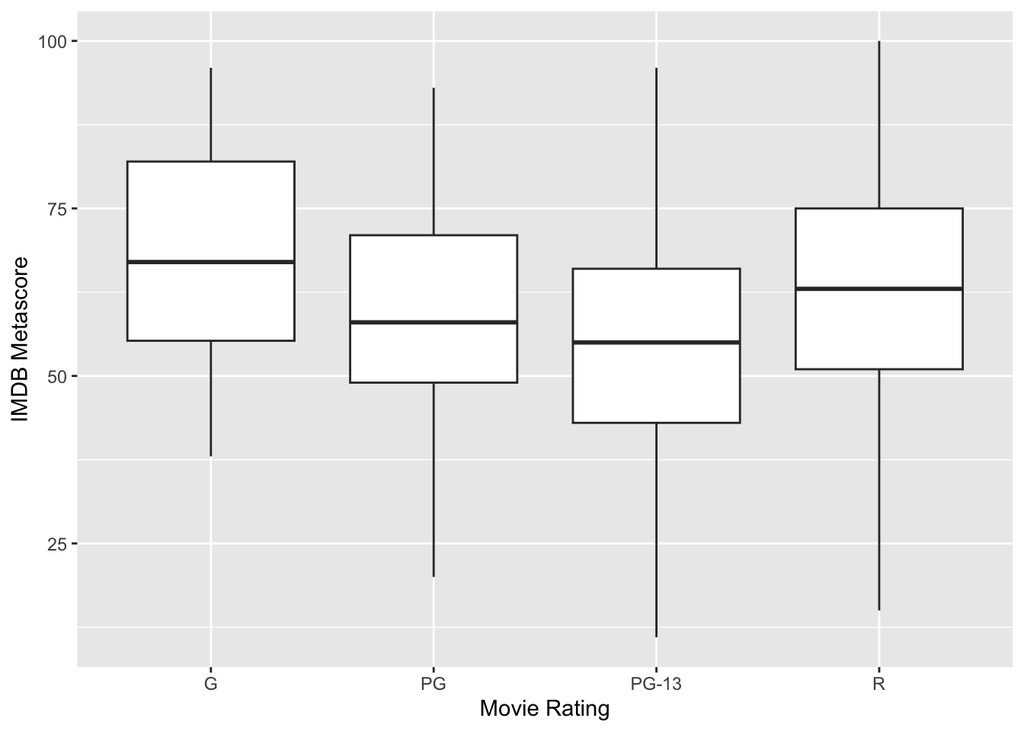

```r
ggplot(movies_select, aes(x = rated, y = metascore))+
  geom_boxplot()+
  labs(x= "Movie Rating", y = "IMDB Metascore")
```

You can also add a title with “title =”.

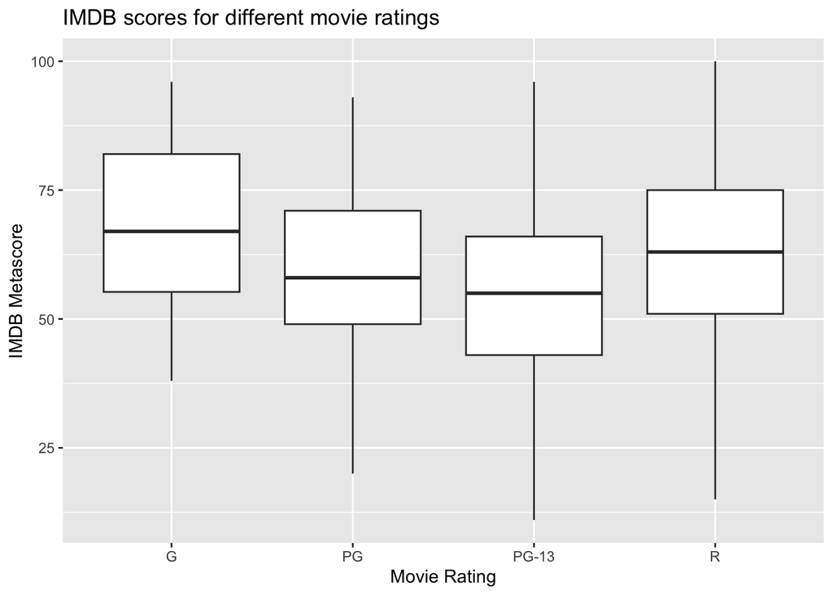

```r
ggplot(movies_select, aes(x = rated, y = metascore))+
  geom_boxplot()+
  labs(x= "Movie Rating", y = "IMDB Metascore", title = "IMDB scores for different movie ratings")
```

### Theme

The default in ggplot is to use have the background as gray with white gridlines. There are layers to edit the background and gridlines. But the easiest way to change the overall look of the plot is to change the “theme” of the plot. There are several different themes that can be “added” to a plot. We will use one called `theme_minimal`. To see a full list, see the help file for the themes type `?theme_minimal`

[figure not shown]

```r
ggplot(movies_select, aes(x = rated, y = metascore))+
  geom_boxplot()+
  labs(x= "Movie Rating", y = "IMDB Metascore", title = "IMDB scores for different movie ratings")+
  theme_minimal()
```

**Exercise**: Play around with the different themes to find one you like.

### Color

You can also change the color in ggplot using the ‘color’ or ‘fill’ argument. Color is used to change the color of the outline, and fill is used to color the inside of a shape. For geom_boxplot(), you would change the color of the lines with `color =` and the inner color of the boxes with `fill =` .

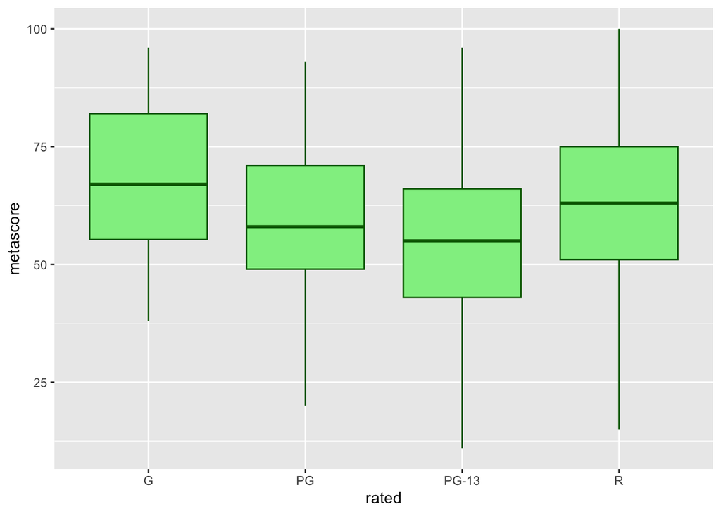

```r
ggplot(movies_select, aes(x = rated, y = metascore))+
  geom_boxplot(color = 'darkgreen', fill = 'lightgreen')
```

Let’s say you are plotting a scatterplot of the budget and the metascore. You can change the color of the points with `color =` inside the `geom_point()` function.

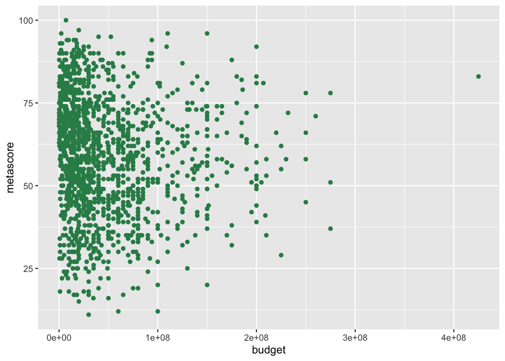

```r
ggplot(data = movies_select, aes(x = budget, y = metascore )) +
  geom_point(color = 'seagreen')
```

To see a full list of colors you can use, see R color chart.

### Other customizations

In the layers, you can also change other aspects including

- size: `size =`
- shape of points: `shape =`
- line type (ex. dashed, solid): `linetype =`

For a list of the aesthetics, see https://ggplot2.tidyverse.org/articles/ggplot2-specs.html

### Color Aesthetics

So far we have changed the color of all the data. However, a very useful way to use color is to base the color on a different variable, or column in the data.

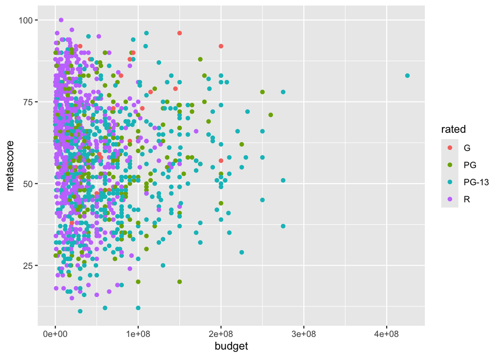

```r
ggplot(data = movies_select, aes(x = budget, y = metascore )) +
  geom_point(aes(color = rated))
```

## Exercises

For homework, continue working with the Raleigh climate data from the `dplyr` [lesson](https://maryglover.github.io/bio331/lessons/data-manip/data-manip-exercise.html).

1. Read in the climate data set. It is in your data folder as “raleigh_prism_climate.csv”
2. Make a histogram of the precipitation data.
3. What do you notice about the precipitation data? Write your answer as a comment in your R script.
4. Filter the data set to only include data from your birth year. Assign the data a new name
5. Make a scatter plot using the data you just made with your birth year. Again, plot the mean temperature data by the month data.
6. Connect the dots from the last plot to make a line graph. To do this, you will add a line plot layer to the previously made graph. The line plot layer is `geom_line()`
7. Do you notice a pattern? Comment your answer in the script.
8. Using the same graph of your birth year and mean temperature, change the color of the line.
9. Using the same graph, change the *theme* of the graph.
10. Using the same graph, add a title to the graph.

## New functions

- `ggplot()`
- `geom_*()`
- `labs()`
- `theme_*()`

## Resources

- [R for Data Science intro](https://r4ds.hadley.nz/data-visualize)
- [R for Data Science advanced](https://r4ds.hadley.nz/layers)
- [R graph gallery](https://r-graph-gallery.com/boxplot.html) This has many examples with code. [Graphing with ggplot2 lesson](https://sesync-ci.github.io/graphics-with-ggplot2-lesson)